# Project: Investigate a Dataset (Gun-data and U.S.-Census-data)

- Introduction
- Data Wrangling
- Exploratory Data Analysis
- Conclusions

## Introduction

**Questions to be answered** are below:

- What census data is most associated with high gun per capita?
- Which states have had the highest growth in gun registrations?
- What is the overall trend of gun purchases?

```python
import pandas as pd
import numpy as np
import seaborn as sns
import matplotlib.pyplot as plt
%matplotlib inline
```

## Data Wrangling

### General Properties

```python
# Load your data and print out a few lines. Perform operations to inspect data
#   types and look for instances of missing or possibly errant data.

# Gun DataFrame
df_gun = pd.read_excel('gun-data.xlsx')

#Census DataFrame
df_census = pd.read_csv('u.s.-census-data.csv')
```

### Data Cleaning (**Gun-Data**)

```python
df_gun
```

|  | month | state | permit | permit_recheck | handgun | long_gun | other | multiple | admin | prepawn_handgun | ... | returned_other | rentals_handgun | rentals_long_gun | private_sale_handgun | private_sale_long_gun | private_sale_other | return_to_seller_handgun | return_to_seller_long_gun | return_to_seller_other | totals |
| --- | --- | --- | --- | --- | --- | --- | --- | --- | --- | --- | --- | --- | --- | --- | --- | --- | --- | --- | --- | --- | --- |
| 0 | 2017-09 | Alabama | 16717.0 | 0.0 | 5734.0 | 6320.0 | 221.0 | 317 | 0.0 | 15.0 | ... | 0.0 | 0.0 | 0.0 | 9.0 | 16.0 | 3.0 | 0.0 | 0.0 | 3.0 | 32019 |
| 1 | 2017-09 | Alaska | 209.0 | 2.0 | 2320.0 | 2930.0 | 219.0 | 160 | 0.0 | 5.0 | ... | 0.0 | 0.0 | 0.0 | 17.0 | 24.0 | 1.0 | 0.0 | 0.0 | 0.0 | 6303 |
| 2 | 2017-09 | Arizona | 5069.0 | 382.0 | 11063.0 | 7946.0 | 920.0 | 631 | 0.0 | 13.0 | ... | 0.0 | 0.0 | 0.0 | 38.0 | 12.0 | 2.0 | 0.0 | 0.0 | 0.0 | 28394 |
| 3 | 2017-09 | Arkansas | 2935.0 | 632.0 | 4347.0 | 6063.0 | 165.0 | 366 | 51.0 | 12.0 | ... | 0.0 | 0.0 | 0.0 | 13.0 | 23.0 | 0.0 | 0.0 | 2.0 | 1.0 | 17747 |
| 4 | 2017-09 | California | 57839.0 | 0.0 | 37165.0 | 24581.0 | 2984.0 | 0 | 0.0 | 0.0 | ... | 0.0 | 0.0 | 0.0 | 0.0 | 0.0 | 0.0 | 0.0 | 0.0 | 0.0 | 123506 |
| ... | ... | ... | ... | ... | ... | ... | ... | ... | ... | ... | ... | ... | ... | ... | ... | ... | ... | ... | ... | ... | ... |
| 12480 | 1998-11 | Virginia | 0.0 | NaN | 14.0 | 2.0 | NaN | 8 | 0.0 | NaN | ... | NaN | NaN | NaN | NaN | NaN | NaN | NaN | NaN | NaN | 24 |
| 12481 | 1998-11 | Washington | 1.0 | NaN | 65.0 | 286.0 | NaN | 8 | 1.0 | NaN | ... | NaN | NaN | NaN | NaN | NaN | NaN | NaN | NaN | NaN | 361 |
| 12482 | 1998-11 | West Virginia | 3.0 | NaN | 149.0 | 251.0 | NaN | 5 | 0.0 | NaN | ... | NaN | NaN | NaN | NaN | NaN | NaN | NaN | NaN | NaN | 408 |
| 12483 | 1998-11 | Wisconsin | 0.0 | NaN | 25.0 | 214.0 | NaN | 2 | 0.0 | NaN | ... | NaN | NaN | NaN | NaN | NaN | NaN | NaN | NaN | NaN | 241 |
| 12484 | 1998-11 | Wyoming | 8.0 | NaN | 45.0 | 49.0 | NaN | 5 | 0.0 | NaN | ... | NaN | NaN | NaN | NaN | NaN | NaN | NaN | NaN | NaN | 107 |

12485 rows × 27 columns

```python
df_gun.head()
```

|  | month | state | permit | permit_recheck | handgun | long_gun | other | multiple | admin | prepawn_handgun | ... | returned_other | rentals_handgun | rentals_long_gun | private_sale_handgun | private_sale_long_gun | private_sale_other | return_to_seller_handgun | return_to_seller_long_gun | return_to_seller_other | totals |
| --- | --- | --- | --- | --- | --- | --- | --- | --- | --- | --- | --- | --- | --- | --- | --- | --- | --- | --- | --- | --- | --- |
| 0 | 2017-09 | Alabama | 16717.0 | 0.0 | 5734.0 | 6320.0 | 221.0 | 317 | 0.0 | 15.0 | ... | 0.0 | 0.0 | 0.0 | 9.0 | 16.0 | 3.0 | 0.0 | 0.0 | 3.0 | 32019 |
| 1 | 2017-09 | Alaska | 209.0 | 2.0 | 2320.0 | 2930.0 | 219.0 | 160 | 0.0 | 5.0 | ... | 0.0 | 0.0 | 0.0 | 17.0 | 24.0 | 1.0 | 0.0 | 0.0 | 0.0 | 6303 |
| 2 | 2017-09 | Arizona | 5069.0 | 382.0 | 11063.0 | 7946.0 | 920.0 | 631 | 0.0 | 13.0 | ... | 0.0 | 0.0 | 0.0 | 38.0 | 12.0 | 2.0 | 0.0 | 0.0 | 0.0 | 28394 |
| 3 | 2017-09 | Arkansas | 2935.0 | 632.0 | 4347.0 | 6063.0 | 165.0 | 366 | 51.0 | 12.0 | ... | 0.0 | 0.0 | 0.0 | 13.0 | 23.0 | 0.0 | 0.0 | 2.0 | 1.0 | 17747 |
| 4 | 2017-09 | California | 57839.0 | 0.0 | 37165.0 | 24581.0 | 2984.0 | 0 | 0.0 | 0.0 | ... | 0.0 | 0.0 | 0.0 | 0.0 | 0.0 | 0.0 | 0.0 | 0.0 | 0.0 | 123506 |

5 rows × 27 columns

```python
df_gun.shape
```

```
(12485, 27)
```

```python
df_gun.info()
```

```
<class 'pandas.core.frame.DataFrame'>
RangeIndex: 12485 entries, 0 to 12484
Data columns (total 27 columns):
 #   Column                     Non-Null Count  Dtype
---  ------                     --------------  -----
 0   month                      12485 non-null  object
 1   state                      12485 non-null  object
 2   permit                     12461 non-null  float64
 3   permit_recheck             1100 non-null   float64
 4   handgun                    12465 non-null  float64
 5   long_gun                   12466 non-null  float64
 6   other                      5500 non-null   float64
 7   multiple                   12485 non-null  int64
 8   admin                      12462 non-null  float64
 9   prepawn_handgun            10542 non-null  float64
```

[output cut: 19 more lines]

```python
df_gun.describe()
```

|  | permit | permit_recheck | handgun | long_gun | other | multiple | admin | prepawn_handgun | prepawn_long_gun | prepawn_other | ... | returned_other | rentals_handgun | rentals_long_gun | private_sale_handgun | private_sale_long_gun | private_sale_other | return_to_seller_handgun | return_to_seller_long_gun | return_to_seller_other | totals |
| --- | --- | --- | --- | --- | --- | --- | --- | --- | --- | --- | --- | --- | --- | --- | --- | --- | --- | --- | --- | --- | --- |
| count | 12461.000000 | 1100.000000 | 12465.000000 | 12466.000000 | 5500.000000 | 12485.000000 | 12462.000000 | 10542.000000 | 10540.000000 | 5115.000000 | ... | 1815.000000 | 990.000000 | 825.000000 | 2750.000000 | 2750.000000 | 2750.000000 | 2475.000000 | 2750.000000 | 2255.000000 | 12485.000000 |
| mean | 6413.629404 | 1165.956364 | 5940.881107 | 7810.847585 | 360.471636 | 268.603364 | 58.898090 | 4.828021 | 7.834156 | 0.165591 | ... | 1.027548 | 0.076768 | 0.087273 | 14.936000 | 11.602909 | 1.030182 | 0.402020 | 0.441818 | 0.105987 | 21595.725911 |
| std | 23752.338269 | 9224.200609 | 8618.584060 | 9309.846140 | 1349.478273 | 783.185073 | 604.814818 | 10.907756 | 16.468028 | 1.057105 | ... | 4.386296 | 0.634503 | 0.671649 | 71.216021 | 54.253090 | 4.467843 | 1.446568 | 1.528223 | 0.427363 | 32591.418387 |
| min | 0.000000 | 0.000000 | 0.000000 | 0.000000 | 0.000000 | 0.000000 | 0.000000 | 0.000000 | 0.000000 | 0.000000 | ... | 0.000000 | 0.000000 | 0.000000 | 0.000000 | 0.000000 | 0.000000 | 0.000000 | 0.000000 | 0.000000 | 0.000000 |
| 25% | 0.000000 | 0.000000 | 865.000000 | 2078.250000 | 17.000000 | 15.000000 | 0.000000 | 0.000000 | 0.000000 | 0.000000 | ... | 0.000000 | 0.000000 | 0.000000 | 0.000000 | 0.000000 | 0.000000 | 0.000000 | 0.000000 | 0.000000 | 4638.000000 |
| 50% | 518.000000 | 0.000000 | 3059.000000 | 5122.000000 | 121.000000 | 125.000000 | 0.000000 | 0.000000 | 1.000000 | 0.000000 | ... | 0.000000 | 0.000000 | 0.000000 | 0.000000 | 0.000000 | 0.000000 | 0.000000 | 0.000000 | 0.000000 | 12399.000000 |
| 75% | 4272.000000 | 0.000000 | 7280.000000 | 10380.750000 | 354.000000 | 301.000000 | 0.000000 | 5.000000 | 8.000000 | 0.000000 | ... | 0.000000 | 0.000000 | 0.000000 | 2.000000 | 4.000000 | 0.000000 | 0.000000 | 0.000000 | 0.000000 | 25453.000000 |
| max | 522188.000000 | 116681.000000 | 107224.000000 | 108058.000000 | 77929.000000 | 38907.000000 | 28083.000000 | 164.000000 | 269.000000 | 49.000000 | ... | 64.000000 | 12.000000 | 12.000000 | 1017.000000 | 777.000000 | 71.000000 | 28.000000 | 17.000000 | 4.000000 | 541978.000000 |

8 rows × 25 columns

```python
df_gun.dtypes
```

```
month                         object
state                         object
permit                       float64
permit_recheck               float64
handgun                      float64
long_gun                     float64
other                        float64
multiple                       int64
admin                        float64
prepawn_handgun              float64
prepawn_long_gun             float64
prepawn_other                float64
redemption_handgun           float64
redemption_long_gun          float64
redemption_other             float64
returned_handgun             float64
returned_long_gun            float64
returned_other               float64
rentals_handgun              float64
rentals_long_gun             float64
private_sale_handgun         float64
private_sale_long_gun        float64
private_sale_other           float64
return_to_seller_handgun     float64
return_to_seller_long_gun    float64
return_to_seller_other       float64
totals                         int64
dtype: object
```

**Briefly look at Census data to check for some consistency**

```python
df_census.head(1)
```

|  | Fact | Fact Note | Alabama | Alaska | Arizona | Arkansas | California | Colorado | Connecticut | Delaware | ... | South Dakota | Tennessee | Texas | Utah | Vermont | Virginia | Washington | West Virginia | Wisconsin | Wyoming |
| --- | --- | --- | --- | --- | --- | --- | --- | --- | --- | --- | --- | --- | --- | --- | --- | --- | --- | --- | --- | --- | --- |
| 0 | Population estimates, July 1, 2016, (V2016) | NaN | 4,863,300 | 741,894 | 6,931,071 | 2,988,248 | 39,250,017 | 5,540,545 | 3,576,452 | 952,065 | ... | 865454 | 6651194 | 27,862,596 | 3,051,217 | 624,594 | 8,411,808 | 7,288,000 | 1,831,102 | 5,778,708 | 585,501 |

1 rows × 52 columns

```python
df_census.iloc[0].index
```

```
Index(['Fact', 'Fact Note', 'Alabama', 'Alaska', 'Arizona', 'Arkansas',
       'California', 'Colorado', 'Connecticut', 'Delaware', 'Florida',
       'Georgia', 'Hawaii', 'Idaho', 'Illinois', 'Indiana', 'Iowa', 'Kansas',
       'Kentucky', 'Louisiana', 'Maine', 'Maryland', 'Massachusetts',
       'Michigan', 'Minnesota', 'Mississippi', 'Missouri', 'Montana',
       'Nebraska', 'Nevada', 'New Hampshire', 'New Jersey', 'New Mexico',
       'New York', 'North Carolina', 'North Dakota', 'Ohio', 'Oklahoma',
       'Oregon', 'Pennsylvania', 'Rhode Island', 'South Carolina',
       'South Dakota', 'Tennessee', 'Texas', 'Utah', 'Vermont', 'Virginia',
       'Washington', 'West Virginia', 'Wisconsin', 'Wyoming'],
      dtype='object')
```

```python
us_label = df_census.iloc[0].index
us_states = us_label[2:]
```

```python
us_states
```

```
Index(['Alabama', 'Alaska', 'Arizona', 'Arkansas', 'California', 'Colorado',
       'Connecticut', 'Delaware', 'Florida', 'Georgia', 'Hawaii', 'Idaho',
       'Illinois', 'Indiana', 'Iowa', 'Kansas', 'Kentucky', 'Louisiana',
       'Maine', 'Maryland', 'Massachusetts', 'Michigan', 'Minnesota',
       'Mississippi', 'Missouri', 'Montana', 'Nebraska', 'Nevada',
       'New Hampshire', 'New Jersey', 'New Mexico', 'New York',
       'North Carolina', 'North Dakota', 'Ohio', 'Oklahoma', 'Oregon',
       'Pennsylvania', 'Rhode Island', 'South Carolina', 'South Dakota',
       'Tennessee', 'Texas', 'Utah', 'Vermont', 'Virginia', 'Washington',
       'West Virginia', 'Wisconsin', 'Wyoming'],
      dtype='object')
```

```python
len(us_states)
```

```
50
```

**Comapare with Census states with states for Gun Data**

```python
df_gun.groupby('state').sum().index
```

```
Index(['Alabama', 'Alaska', 'Arizona', 'Arkansas', 'California', 'Colorado',
       'Connecticut', 'Delaware', 'District of Columbia', 'Florida', 'Georgia',
       'Guam', 'Hawaii', 'Idaho', 'Illinois', 'Indiana', 'Iowa', 'Kansas',
       'Kentucky', 'Louisiana', 'Maine', 'Mariana Islands', 'Maryland',
       'Massachusetts', 'Michigan', 'Minnesota', 'Mississippi', 'Missouri',
       'Montana', 'Nebraska', 'Nevada', 'New Hampshire', 'New Jersey',
       'New Mexico', 'New York', 'North Carolina', 'North Dakota', 'Ohio',
       'Oklahoma', 'Oregon', 'Pennsylvania', 'Puerto Rico', 'Rhode Island',
       'South Carolina', 'South Dakota', 'Tennessee', 'Texas', 'Utah',
       'Vermont', 'Virgin Islands', 'Virginia', 'Washington', 'West Virginia',
       'Wisconsin', 'Wyoming'],
      dtype='object', name='state')
```

```python
gun_states = df_gun.groupby('state').sum().index
len(gun_states)
```

```
55
```

```python
for states in gun_states:
    if states not in us_states:
        print(states)
```

```
District of Columbia
Guam
Mariana Islands
Puerto Rico
Virgin Islands
```

**Remove the Above states from Gun-data**

```python
df_gun = df_gun[df_gun.state != 'Guam']
df_gun = df_gun[df_gun.state != 'Puerto Rico']
df_gun = df_gun[df_gun.state != 'District of Columbia']
df_gun = df_gun[df_gun.state != 'Virgin Islands']
df_gun = df_gun[df_gun.state != 'Mariana Islands']
```

```python
#confirm they are no longer available
gun_states = df_gun.groupby('state').sum().index
len(gun_states)
```

```
50
```

**Drop invalid columns needed for Guns per capita calculations**

```python
gun_per_capita = df_gun.drop([ 'permit', 'permit_recheck', 'handgun',
       'long_gun', 'other', 'multiple', 'admin', 'prepawn_handgun',
       'prepawn_long_gun', 'prepawn_other', 'redemption_handgun',
       'redemption_long_gun', 'redemption_other', 'returned_handgun',
       'returned_long_gun', 'returned_other', 'rentals_handgun',
       'rentals_long_gun', 'private_sale_handgun',
       'private_sale_long_gun', 'private_sale_other',
       'return_to_seller_handgun', 'return_to_seller_long_gun',
       'return_to_seller_other'], axis = 1)
```

```python
gun_per_capita.head()
```

|  | month | state | totals |
| --- | --- | --- | --- |
| 0 | 2017-09 | Alabama | 32019 |
| 1 | 2017-09 | Alaska | 6303 |
| 2 | 2017-09 | Arizona | 28394 |
| 3 | 2017-09 | Arkansas | 17747 |
| 4 | 2017-09 | California | 123506 |

```python
gun_per_capita.info()
```

```
<class 'pandas.core.frame.DataFrame'>
Int64Index: 11350 entries, 0 to 12484
Data columns (total 3 columns):
 #   Column  Non-Null Count  Dtype
---  ------  --------------  -----
 0   month   11350 non-null  object
 1   state   11350 non-null  object
 2   totals  11350 non-null  int64
dtypes: int64(1), object(2)
memory usage: 354.7+ KB
```

```python
gun_per_capita.describe()
```

|  | totals |
| --- | --- |
| count | 11350.000000 |
| mean | 23734.978502 |
| std | 33437.577310 |
| min | 6.000000 |
| 25% | 6472.000000 |
| 50% | 14050.000000 |
| 75% | 27537.000000 |
| max | 541978.000000 |

**Create consistency in dates**

```python
# We need months of 1st April 2010 and 1st of July 2016 from gun data for consistency with census data
#1. convert date time in strings to date time
gun_per_capita['month'] = pd.to_datetime(df_gun['month'])
```

```python
# 2. confirm dtype has changed.
gun_per_capita.month.dtype
```

```
dtype('<M8[ns]')
```

```python
gun_per_capita.info()
```

```
<class 'pandas.core.frame.DataFrame'>
Int64Index: 11350 entries, 0 to 12484
Data columns (total 3 columns):
 #   Column  Non-Null Count  Dtype
---  ------  --------------  -----
 0   month   11350 non-null  datetime64[ns]
 1   state   11350 non-null  object
 2   totals  11350 non-null  int64
dtypes: datetime64[ns](1), int64(1), object(1)
memory usage: 354.7+ KB
```

*Fetch all data of "1st of April 2010"*

```python
guns_of_2010 = gun_per_capita[gun_per_capita['month'] == '2010-04-01']
guns_of_2010.head()
```

|  | month | state | totals |
| --- | --- | --- | --- |
| 4895 | 2010-04-01 | Alabama | 20791 |
| 4896 | 2010-04-01 | Alaska | 6411 |
| 4897 | 2010-04-01 | Arizona | 16578 |
| 4898 | 2010-04-01 | Arkansas | 14563 |
| 4899 | 2010-04-01 | California | 80750 |

*Fetch all data of "1st of July 2016"*

```python
guns_of_2016 = gun_per_capita[gun_per_capita['month'] == '2016-07-01']
guns_of_2016.head()
```

|  | month | state | totals |
| --- | --- | --- | --- |
| 770 | 2016-07-01 | Alabama | 48927 |
| 771 | 2016-07-01 | Alaska | 6793 |
| 772 | 2016-07-01 | Arizona | 34496 |
| 773 | 2016-07-01 | Arkansas | 19378 |
| 774 | 2016-07-01 | California | 190218 |

```python
guns_of_2010.describe()
```

|  | totals |
| --- | --- |
| count | 50.0000 |
| mean | 24517.7400 |
| std | 34280.1673 |
| min | 963.0000 |
| 25% | 7197.5000 |
| 50% | 15242.5000 |
| 75% | 26335.5000 |
| max | 211261.0000 |

```python
guns_of_2016.describe()
```

|  | totals |
| --- | --- |
| count | 50.000000 |
| mean | 43710.400000 |
| std | 61544.999748 |
| min | 1565.000000 |
| 25% | 11823.000000 |
| 50% | 25379.500000 |
| 75% | 46008.500000 |
| max | 363085.000000 |

**Concatinate Both data of 2010 and 2016**

```python
joined_guns = pd.concat([guns_of_2010, guns_of_2016], keys=['2010-04-01', '2016-07-01'], axis = 0)
joined_guns.head()
```

|  |  | month | state | totals |
| --- | --- | --- | --- | --- |
| 2010-04-01 | 4895 | 2010-04-01 | Alabama | 20791 |
|  | 4896 | 2010-04-01 | Alaska | 6411 |
|  | 4897 | 2010-04-01 | Arizona | 16578 |
|  | 4898 | 2010-04-01 | Arkansas | 14563 |
|  | 4899 | 2010-04-01 | California | 80750 |

```python
joined_guns.reset_index(drop=True, inplace=True)
```

```python
joined_guns
```

|  | month | state | totals |
| --- | --- | --- | --- |
| 0 | 2010-04-01 | Alabama | 20791 |
| 1 | 2010-04-01 | Alaska | 6411 |
| 2 | 2010-04-01 | Arizona | 16578 |
| 3 | 2010-04-01 | Arkansas | 14563 |
| 4 | 2010-04-01 | California | 80750 |
| ... | ... | ... | ... |
| 95 | 2016-07-01 | Virginia | 43574 |
| 96 | 2016-07-01 | Washington | 47887 |
| 97 | 2016-07-01 | West Virginia | 16791 |
| 98 | 2016-07-01 | Wisconsin | 38922 |
| 99 | 2016-07-01 | Wyoming | 4585 |

100 rows × 3 columns

### Data Cleaning (U.S. - Cenus Data)

```python
df_census.head()
```

|  | Fact | Fact Note | Alabama | Alaska | Arizona | Arkansas | California | Colorado | Connecticut | Delaware | ... | South Dakota | Tennessee | Texas | Utah | Vermont | Virginia | Washington | West Virginia | Wisconsin | Wyoming |
| --- | --- | --- | --- | --- | --- | --- | --- | --- | --- | --- | --- | --- | --- | --- | --- | --- | --- | --- | --- | --- | --- |
| 0 | Population estimates, July 1, 2016, (V2016) | NaN | 4,863,300 | 741,894 | 6,931,071 | 2,988,248 | 39,250,017 | 5,540,545 | 3,576,452 | 952,065 | ... | 865454 | 6651194 | 27,862,596 | 3,051,217 | 624,594 | 8,411,808 | 7,288,000 | 1,831,102 | 5,778,708 | 585,501 |
| 1 | Population estimates base, April 1, 2010, (V2... | NaN | 4,780,131 | 710,249 | 6,392,301 | 2,916,025 | 37,254,522 | 5,029,324 | 3,574,114 | 897,936 | ... | 814195 | 6346298 | 25,146,100 | 2,763,888 | 625,741 | 8,001,041 | 6,724,545 | 1,853,011 | 5,687,289 | 563,767 |
| 2 | Population, percent change - April 1, 2010 (es... | NaN | 1.70% | 4.50% | 8.40% | 2.50% | 5.40% | 10.20% | 0.10% | 6.00% | ... | 0.063 | 0.048 | 10.80% | 10.40% | -0.20% | 5.10% | 8.40% | -1.20% | 1.60% | 3.90% |
| 3 | Population, Census, April 1, 2010 | NaN | 4,779,736 | 710,231 | 6,392,017 | 2,915,918 | 37,253,956 | 5,029,196 | 3,574,097 | 897,934 | ... | 814180 | 6346105 | 25,145,561 | 2,763,885 | 625,741 | 8,001,024 | 6,724,540 | 1,852,994 | 5,686,986 | 563,626 |
| 4 | Persons under 5 years, percent, July 1, 2016, ... | NaN | 6.00% | 7.30% | 6.30% | 6.40% | 6.30% | 6.10% | 5.20% | 5.80% | ... | 0.071 | 0.061 | 7.20% | 8.30% | 4.90% | 6.10% | 6.20% | 5.50% | 5.80% | 6.50% |

5 rows × 52 columns

```python
#Drop the fact note since it isn't necessary for analysis
df_census=df_census.drop('Fact Note',axis=1)
```

```python
#set fact column as index
df_census.set_index('Fact',inplace=True)
```

```python
#Transpose the dataframe to make it make sense(Presentable)
df_census = df_census.T.reset_index()
```

```python
df_census.head()
```

| Fact | index | Population estimates, July 1, 2016, (V2016) | Population estimates base, April 1, 2010, (V2016) | Population, percent change - April 1, 2010 (estimates base) to July 1, 2016, (V2016) | Population, Census, April 1, 2010 | Persons under 5 years, percent, July 1, 2016, (V2016) | Persons under 5 years, percent, April 1, 2010 | Persons under 18 years, percent, July 1, 2016, (V2016) | Persons under 18 years, percent, April 1, 2010 | Persons 65 years and over, percent, July 1, 2016, (V2016) | ... | NaN | Value Flags | - | D | F | FN | NaN | S | X | Z |
| --- | --- | --- | --- | --- | --- | --- | --- | --- | --- | --- | --- | --- | --- | --- | --- | --- | --- | --- | --- | --- | --- |
| 0 | Alabama | 4,863,300 | 4,780,131 | 1.70% | 4,779,736 | 6.00% | 6.40% | 22.60% | 23.70% | 16.10% | ... | NaN | NaN | NaN | NaN | NaN | NaN | NaN | NaN | NaN | NaN |
| 1 | Alaska | 741,894 | 710,249 | 4.50% | 710,231 | 7.30% | 7.60% | 25.20% | 26.40% | 10.40% | ... | NaN | NaN | NaN | NaN | NaN | NaN | NaN | NaN | NaN | NaN |
| 2 | Arizona | 6,931,071 | 6,392,301 | 8.40% | 6,392,017 | 6.30% | 7.10% | 23.50% | 25.50% | 16.90% | ... | NaN | NaN | NaN | NaN | NaN | NaN | NaN | NaN | NaN | NaN |
| 3 | Arkansas | 2,988,248 | 2,916,025 | 2.50% | 2,915,918 | 6.40% | 6.80% | 23.60% | 24.40% | 16.30% | ... | NaN | NaN | NaN | NaN | NaN | NaN | NaN | NaN | NaN | NaN |
| 4 | California | 39,250,017 | 37,254,522 | 5.40% | 37,253,956 | 6.30% | 6.80% | 23.20% | 25.00% | 13.60% | ... | NaN | NaN | NaN | NaN | NaN | NaN | NaN | NaN | NaN | NaN |

5 rows × 86 columns

```python
df_census.info()
```

```
<class 'pandas.core.frame.DataFrame'>
RangeIndex: 50 entries, 0 to 49
Data columns (total 86 columns):
 #   Column                                                                                  Non-Null Count  Dtype
---  ------                                                                                  --------------  -----
 0   index                                                                                   50 non-null     object
 1   Population estimates, July 1, 2016,  (V2016)                                            50 non-null     object
 2   Population estimates base, April 1, 2010,  (V2016)                                      50 non-null     object
 3   Population, percent change - April 1, 2010 (estimates base) to July 1, 2016,  (V2016)   50 non-null     object
 4   Population, Census, April 1, 2010                                                       50 non-null     object
 5   Persons under 5 years, percent, July 1, 2016,  (V2016)                                  50 non-null     object
 6   Persons under 5 years, percent, April 1, 2010                                           50 non-null     object
 7   Persons under 18 years, percent, July 1, 2016,  (V2016)                                 50 non-null     object
 8   Persons under 18 years, percent, April 1, 2010                                          50 non-null     object
 9   Persons 65 years and over, percent,  July 1, 2016,  (V2016)                             50 non-null     object
```

[output cut: 78 more lines]

```python
#Drop all irrelevant columns
df_census.drop(df_census.iloc[:, 66:86], inplace = True, axis = 1)
```

```python
#Replace the NAN
df_census = df_census.fillna(0.0)
```

```python
#Rename index column to state
df_census.rename(columns={'index':'state'},inplace = True)
```

```python
df_census.head(1)
```

| Fact | state | Population estimates, July 1, 2016, (V2016) | Population estimates base, April 1, 2010, (V2016) | Population, percent change - April 1, 2010 (estimates base) to July 1, 2016, (V2016) | Population, Census, April 1, 2010 | Persons under 5 years, percent, July 1, 2016, (V2016) | Persons under 5 years, percent, April 1, 2010 | Persons under 18 years, percent, July 1, 2016, (V2016) | Persons under 18 years, percent, April 1, 2010 | Persons 65 years and over, percent, July 1, 2016, (V2016) | ... | All firms, 2012 | Men-owned firms, 2012 | Women-owned firms, 2012 | Minority-owned firms, 2012 | Nonminority-owned firms, 2012 | Veteran-owned firms, 2012 | Nonveteran-owned firms, 2012 | Population per square mile, 2010 | Land area in square miles, 2010 | FIPS Code |
| --- | --- | --- | --- | --- | --- | --- | --- | --- | --- | --- | --- | --- | --- | --- | --- | --- | --- | --- | --- | --- | --- |
| 0 | Alabama | 4,863,300 | 4,780,131 | 1.70% | 4,779,736 | 6.00% | 6.40% | 22.60% | 23.70% | 16.10% | ... | 374,153 | 203,604 | 137,630 | 92,219 | 272,651 | 41,943 | 316,984 | 94.4 | 50,645.33 | "01" |

1 rows × 66 columns

```python
#confirm columns are Okay
df_census.info()
```

```
<class 'pandas.core.frame.DataFrame'>
RangeIndex: 50 entries, 0 to 49
Data columns (total 66 columns):
 #   Column                                                                                  Non-Null Count  Dtype
---  ------                                                                                  --------------  -----
 0   state                                                                                   50 non-null     object
 1   Population estimates, July 1, 2016,  (V2016)                                            50 non-null     object
 2   Population estimates base, April 1, 2010,  (V2016)                                      50 non-null     object
 3   Population, percent change - April 1, 2010 (estimates base) to July 1, 2016,  (V2016)   50 non-null     object
 4   Population, Census, April 1, 2010                                                       50 non-null     object
 5   Persons under 5 years, percent, July 1, 2016,  (V2016)                                  50 non-null     object
 6   Persons under 5 years, percent, April 1, 2010                                           50 non-null     object
 7   Persons under 18 years, percent, July 1, 2016,  (V2016)                                 50 non-null     object
 8   Persons under 18 years, percent, April 1, 2010                                          50 non-null     object
 9   Persons 65 years and over, percent,  July 1, 2016,  (V2016)                             50 non-null     object
```

[output cut: 58 more lines]

```python
#Check for missing Values
df_check = df_census[df_census.isna().any(axis=1)]
df_check.head()

# - NO MISSING VALUES FOUND.
```

| Fact | state | Population estimates, July 1, 2016, (V2016) | Population estimates base, April 1, 2010, (V2016) | Population, percent change - April 1, 2010 (estimates base) to July 1, 2016, (V2016) | Population, Census, April 1, 2010 | Persons under 5 years, percent, July 1, 2016, (V2016) | Persons under 5 years, percent, April 1, 2010 | Persons under 18 years, percent, July 1, 2016, (V2016) | Persons under 18 years, percent, April 1, 2010 | Persons 65 years and over, percent, July 1, 2016, (V2016) | ... | All firms, 2012 | Men-owned firms, 2012 | Women-owned firms, 2012 | Minority-owned firms, 2012 | Nonminority-owned firms, 2012 | Veteran-owned firms, 2012 | Nonveteran-owned firms, 2012 | Population per square mile, 2010 | Land area in square miles, 2010 | FIPS Code |
| --- | --- | --- | --- | --- | --- | --- | --- | --- | --- | --- | --- | --- | --- | --- | --- | --- | --- | --- | --- | --- | --- |

0 rows × 66 columns

```python
#creating a new dataframe with only these columns
df_census_16 = df_census[['state', 'Population estimates, July 1, 2016,  (V2016)']]
df_census_16.head()
```

| Fact | state | Population estimates, July 1, 2016, (V2016) |
| --- | --- | --- |
| 0 | Alabama | 4,863,300 |
| 1 | Alaska | 741,894 |
| 2 | Arizona | 6,931,071 |
| 3 | Arkansas | 2,988,248 |
| 4 | California | 39,250,017 |

```python
#Replace ',' to this ''.
df_census_16['Population estimates, July 1, 2016,  (V2016)'].replace(to_replace=',',value=r'',regex=True,inplace=True)
```

```python
df_census_16.head()
```

| Fact | state | Population estimates, July 1, 2016, (V2016) |
| --- | --- | --- |
| 0 | Alabama | 4863300 |
| 1 | Alaska | 741894 |
| 2 | Arizona | 6931071 |
| 3 | Arkansas | 2988248 |
| 4 | California | 39250017 |

```python
df_census_16.dtypes
```

```
Fact
state                                           object
Population estimates, July 1, 2016,  (V2016)    object
dtype: object
```

```python
#Convert Population estimates, July 1, 2016, (V2016) from object to float
df_census_16['Population estimates, July 1, 2016,  (V2016)']= pd.to_numeric(df_census_16['Population estimates, July 1, 2016,  (V2016)'], downcast='float', errors='ignore')
```

```python
df_census_16.info()
```

```
<class 'pandas.core.frame.DataFrame'>
RangeIndex: 50 entries, 0 to 49
Data columns (total 2 columns):
 #   Column                                        Non-Null Count  Dtype
---  ------                                        --------------  -----
 0   state                                         50 non-null     object
 1   Population estimates, July 1, 2016,  (V2016)  50 non-null     float32
dtypes: float32(1), object(1)
memory usage: 728.0+ bytes
```

```python
#Find the total of the 'Population estimates, July 1, 2016,  (V2016)' column
total_2016=df_census_16['Population estimates, July 1, 2016,  (V2016)'].sum()
total_2016
```

```
322446340.0
```

```python
#creating a new dataframe with only these columns
df_census_10 = df_census[['state','Population estimates base, April 1, 2010,  (V2016)']]
df_census_10.head()
```

| Fact | state | Population estimates base, April 1, 2010, (V2016) |
| --- | --- | --- |
| 0 | Alabama | 4,780,131 |
| 1 | Alaska | 710,249 |
| 2 | Arizona | 6,392,301 |
| 3 | Arkansas | 2,916,025 |
| 4 | California | 37,254,522 |

```python
#Replace ',' to this ''.
df_census_10['Population estimates base, April 1, 2010,  (V2016)'].replace(to_replace=',',value=r'',regex=True,inplace=True)
```

```python
df_census_10.head(1)
```

| Fact | state | Population estimates base, April 1, 2010, (V2016) |
| --- | --- | --- |
| 0 | Alabama | 4780131 |

```python
#Convert Population estimates, April 1, 2010, (V2016) from object to float
df_census_10['Population estimates base, April 1, 2010,  (V2016)']= pd.to_numeric(df_census_10['Population estimates base, April 1, 2010,  (V2016)'], downcast='float', errors='ignore')
```

```python
df_census_10.info()
```

```
<class 'pandas.core.frame.DataFrame'>
RangeIndex: 50 entries, 0 to 49
Data columns (total 2 columns):
 #   Column                                              Non-Null Count  Dtype
---  ------                                              --------------  -----
 0   state                                               50 non-null     object
 1   Population estimates base, April 1, 2010,  (V2016)  50 non-null     float32
dtypes: float32(1), object(1)
memory usage: 728.0+ bytes
```

```python
#Find the total of the 'Population estimates, July 1, 2016,  (V2016)' column
total_2010 = df_census_10['Population estimates base, April 1, 2010,  (V2016)'].sum()
total_2010
```

```
308156350.0
```

```python
#Prepare df_census_16 for merging
df_census_16.reset_index(drop=True)
df_census_16.head
```

```
<bound method NDFrame.head of Fact           state  Population estimates, July 1, 2016,  (V2016)
0            Alabama                                     4863300.0
1             Alaska                                      741894.0
2            Arizona                                     6931071.0
3           Arkansas                                     2988248.0
4         California                                    39250016.0
5           Colorado                                     5540545.0
6        Connecticut                                     3576452.0
7           Delaware                                      952065.0
8            Florida                                    20612440.0
9            Georgia                                    10310371.0
10            Hawaii                                     1428557.0
11             Idaho                                     1683140.0
12          Illinois                                    12801539.0
13           Indiana                                     6633053.0
```

[output cut: 36 more lines]

```python
#Prepare df_census_10
df_census_10.reset_index(drop=True).head()
```

| Fact | state | Population estimates base, April 1, 2010, (V2016) |
| --- | --- | --- |
| 0 | Alabama | 4780131.0 |
| 1 | Alaska | 710249.0 |
| 2 | Arizona | 6392301.0 |
| 3 | Arkansas | 2916025.0 |
| 4 | California | 37254520.0 |

```python
#merging the Census 2010 and 2016 data
merge_census = df_census_10.merge(df_census_16, on='state', how='left')
merge_census.head()
```

| Fact | state | Population estimates base, April 1, 2010, (V2016) | Population estimates, July 1, 2016, (V2016) |
| --- | --- | --- | --- |
| 0 | Alabama | 4780131.0 | 4863300.0 |
| 1 | Alaska | 710249.0 | 741894.0 |
| 2 | Arizona | 6392301.0 | 6931071.0 |
| 3 | Arkansas | 2916025.0 | 2988248.0 |
| 4 | California | 37254520.0 | 39250016.0 |

```python
guns_of_2010 = guns_of_2010.reset_index(drop= True)
guns_of_2010.head()
```

|  | month | state | totals |
| --- | --- | --- | --- |
| 0 | 2010-04-01 | Alabama | 20791 |
| 1 | 2010-04-01 | Alaska | 6411 |
| 2 | 2010-04-01 | Arizona | 16578 |
| 3 | 2010-04-01 | Arkansas | 14563 |
| 4 | 2010-04-01 | California | 80750 |

```python
guns_of_2016 = guns_of_2016.reset_index(drop= True)
guns_of_2016.head()
```

|  | month | state | totals |
| --- | --- | --- | --- |
| 0 | 2016-07-01 | Alabama | 48927 |
| 1 | 2016-07-01 | Alaska | 6793 |
| 2 | 2016-07-01 | Arizona | 34496 |
| 3 | 2016-07-01 | Arkansas | 19378 |
| 4 | 2016-07-01 | California | 190218 |

```python
#Merge guns of 2010 and 2016
merge_gun = guns_of_2010.merge(guns_of_2016, on='state', how='left')
merge_gun.head()
```

|  | month_x | state | totals_x | month_y | totals_y |
| --- | --- | --- | --- | --- | --- |
| 0 | 2010-04-01 | Alabama | 20791 | 2016-07-01 | 48927 |
| 1 | 2010-04-01 | Alaska | 6411 | 2016-07-01 | 6793 |
| 2 | 2010-04-01 | Arizona | 16578 | 2016-07-01 | 34496 |
| 3 | 2010-04-01 | Arkansas | 14563 | 2016-07-01 | 19378 |
| 4 | 2010-04-01 | California | 80750 | 2016-07-01 | 190218 |

```python
#Per capita is needed in % so we convert the values to percentage
def myPercentage(pct):
    value_in_percentage = pct*100
    return value_in_percentage
```

## Exploratory Data Analysis

### Research Question 1 (What census data is most associated with high gun per capita?)

```python
df_census.head()
```

| Fact | state | Population estimates, July 1, 2016, (V2016) | Population estimates base, April 1, 2010, (V2016) | Population, percent change - April 1, 2010 (estimates base) to July 1, 2016, (V2016) | Population, Census, April 1, 2010 | Persons under 5 years, percent, July 1, 2016, (V2016) | Persons under 5 years, percent, April 1, 2010 | Persons under 18 years, percent, July 1, 2016, (V2016) | Persons under 18 years, percent, April 1, 2010 | Persons 65 years and over, percent, July 1, 2016, (V2016) | ... | All firms, 2012 | Men-owned firms, 2012 | Women-owned firms, 2012 | Minority-owned firms, 2012 | Nonminority-owned firms, 2012 | Veteran-owned firms, 2012 | Nonveteran-owned firms, 2012 | Population per square mile, 2010 | Land area in square miles, 2010 | FIPS Code |
| --- | --- | --- | --- | --- | --- | --- | --- | --- | --- | --- | --- | --- | --- | --- | --- | --- | --- | --- | --- | --- | --- |
| 0 | Alabama | 4,863,300 | 4,780,131 | 1.70% | 4,779,736 | 6.00% | 6.40% | 22.60% | 23.70% | 16.10% | ... | 374,153 | 203,604 | 137,630 | 92,219 | 272,651 | 41,943 | 316,984 | 94.4 | 50,645.33 | "01" |
| 1 | Alaska | 741,894 | 710,249 | 4.50% | 710,231 | 7.30% | 7.60% | 25.20% | 26.40% | 10.40% | ... | 68,032 | 35,402 | 22,141 | 13,688 | 51,147 | 7,953 | 56,091 | 1.2 | 570,640.95 | "02" |
| 2 | Arizona | 6,931,071 | 6,392,301 | 8.40% | 6,392,017 | 6.30% | 7.10% | 23.50% | 25.50% | 16.90% | ... | 499,926 | 245,243 | 182,425 | 135,313 | 344,981 | 46,780 | 427,582 | 56.3 | 113,594.08 | "04" |
| 3 | Arkansas | 2,988,248 | 2,916,025 | 2.50% | 2,915,918 | 6.40% | 6.80% | 23.60% | 24.40% | 16.30% | ... | 231,959 | 123,158 | 75,962 | 35,982 | 189,029 | 25,915 | 192,988 | 56 | 52,035.48 | "05" |
| 4 | California | 39,250,017 | 37,254,522 | 5.40% | 37,253,956 | 6.30% | 6.80% | 23.20% | 25.00% | 13.60% | ... | 3,548,449 | 1,852,580 | 1,320,085 | 1,619,857 | 1,819,107 | 252,377 | 3,176,341 | 239.1 | 155,779.22 | "06" |

5 rows × 66 columns

```python
df_census.info()
```

```
<class 'pandas.core.frame.DataFrame'>
RangeIndex: 50 entries, 0 to 49
Data columns (total 66 columns):
 #   Column                                                                                  Non-Null Count  Dtype
---  ------                                                                                  --------------  -----
 0   state                                                                                   50 non-null     object
 1   Population estimates, July 1, 2016,  (V2016)                                            50 non-null     object
 2   Population estimates base, April 1, 2010,  (V2016)                                      50 non-null     object
 3   Population, percent change - April 1, 2010 (estimates base) to July 1, 2016,  (V2016)   50 non-null     object
 4   Population, Census, April 1, 2010                                                       50 non-null     object
 5   Persons under 5 years, percent, July 1, 2016,  (V2016)                                  50 non-null     object
 6   Persons under 5 years, percent, April 1, 2010                                           50 non-null     object
 7   Persons under 18 years, percent, July 1, 2016,  (V2016)                                 50 non-null     object
 8   Persons under 18 years, percent, April 1, 2010                                          50 non-null     object
 9   Persons 65 years and over, percent,  July 1, 2016,  (V2016)                             50 non-null     object
```

[output cut: 58 more lines]

Insert columns for calculation and visualization of guns per capita

```python
df_census.insert(loc=66, column='guns_per_capita_2010', value='')
```

```python
df_census.insert(loc=67, column='guns_per_capita_2016', value='')
```

```python
#merge census data and merged guns
merge_data = merge_gun.merge(merge_census, on='state', how='inner')
sensible_data = merge_data.merge(df_census, on='state', how='inner')
sensible_data.head()
```

|  | month_x | state | totals_x | month_y | totals_y | Population estimates base, April 1, 2010, (V2016)_x | Population estimates, July 1, 2016, (V2016)_x | Population estimates, July 1, 2016, (V2016)_y | Population estimates base, April 1, 2010, (V2016)_y | Population, percent change - April 1, 2010 (estimates base) to July 1, 2016, (V2016) | ... | Women-owned firms, 2012 | Minority-owned firms, 2012 | Nonminority-owned firms, 2012 | Veteran-owned firms, 2012 | Nonveteran-owned firms, 2012 | Population per square mile, 2010 | Land area in square miles, 2010 | FIPS Code | guns_per_capita_2010 | guns_per_capita_2016 |
| --- | --- | --- | --- | --- | --- | --- | --- | --- | --- | --- | --- | --- | --- | --- | --- | --- | --- | --- | --- | --- | --- |
| 0 | 2010-04-01 | Alabama | 20791 | 2016-07-01 | 48927 | 4780131.0 | 4863300.0 | 4,863,300 | 4,780,131 | 1.70% | ... | 137,630 | 92,219 | 272,651 | 41,943 | 316,984 | 94.4 | 50,645.33 | "01" |  |  |
| 1 | 2010-04-01 | Alaska | 6411 | 2016-07-01 | 6793 | 710249.0 | 741894.0 | 741,894 | 710,249 | 4.50% | ... | 22,141 | 13,688 | 51,147 | 7,953 | 56,091 | 1.2 | 570,640.95 | "02" |  |  |
| 2 | 2010-04-01 | Arizona | 16578 | 2016-07-01 | 34496 | 6392301.0 | 6931071.0 | 6,931,071 | 6,392,301 | 8.40% | ... | 182,425 | 135,313 | 344,981 | 46,780 | 427,582 | 56.3 | 113,594.08 | "04" |  |  |
| 3 | 2010-04-01 | Arkansas | 14563 | 2016-07-01 | 19378 | 2916025.0 | 2988248.0 | 2,988,248 | 2,916,025 | 2.50% | ... | 75,962 | 35,982 | 189,029 | 25,915 | 192,988 | 56 | 52,035.48 | "05" |  |  |
| 4 | 2010-04-01 | California | 80750 | 2016-07-01 | 190218 | 37254520.0 | 39250016.0 | 39,250,017 | 37,254,522 | 5.40% | ... | 1,320,085 | 1,619,857 | 1,819,107 | 252,377 | 3,176,341 | 239.1 | 155,779.22 | "06" |  |  |

5 rows × 74 columns

```python
#calculate Gun_Per_Capital for 2016
sensible_data['guns_per_capita_2016'] = sensible_data['totals_y']/sensible_data['Population estimates, July 1, 2016,  (V2016)_x']
```

```python
#calculate Gun_Per_Capital for 2010
sensible_data['guns_per_capita_2010'] = sensible_data['totals_x']/sensible_data['Population estimates base, April 1, 2010,  (V2016)_x']
```

```python
sensible_data.head()
```

|  | month_x | state | totals_x | month_y | totals_y | Population estimates base, April 1, 2010, (V2016)_x | Population estimates, July 1, 2016, (V2016)_x | Population estimates, July 1, 2016, (V2016)_y | Population estimates base, April 1, 2010, (V2016)_y | Population, percent change - April 1, 2010 (estimates base) to July 1, 2016, (V2016) | ... | Women-owned firms, 2012 | Minority-owned firms, 2012 | Nonminority-owned firms, 2012 | Veteran-owned firms, 2012 | Nonveteran-owned firms, 2012 | Population per square mile, 2010 | Land area in square miles, 2010 | FIPS Code | guns_per_capita_2010 | guns_per_capita_2016 |
| --- | --- | --- | --- | --- | --- | --- | --- | --- | --- | --- | --- | --- | --- | --- | --- | --- | --- | --- | --- | --- | --- |
| 0 | 2010-04-01 | Alabama | 20791 | 2016-07-01 | 48927 | 4780131.0 | 4863300.0 | 4,863,300 | 4,780,131 | 1.70% | ... | 137,630 | 92,219 | 272,651 | 41,943 | 316,984 | 94.4 | 50,645.33 | "01" | 0.004349 | 0.010060 |
| 1 | 2010-04-01 | Alaska | 6411 | 2016-07-01 | 6793 | 710249.0 | 741894.0 | 741,894 | 710,249 | 4.50% | ... | 22,141 | 13,688 | 51,147 | 7,953 | 56,091 | 1.2 | 570,640.95 | "02" | 0.009026 | 0.009156 |
| 2 | 2010-04-01 | Arizona | 16578 | 2016-07-01 | 34496 | 6392301.0 | 6931071.0 | 6,931,071 | 6,392,301 | 8.40% | ... | 182,425 | 135,313 | 344,981 | 46,780 | 427,582 | 56.3 | 113,594.08 | "04" | 0.002593 | 0.004977 |
| 3 | 2010-04-01 | Arkansas | 14563 | 2016-07-01 | 19378 | 2916025.0 | 2988248.0 | 2,988,248 | 2,916,025 | 2.50% | ... | 75,962 | 35,982 | 189,029 | 25,915 | 192,988 | 56 | 52,035.48 | "05" | 0.004994 | 0.006485 |
| 4 | 2010-04-01 | California | 80750 | 2016-07-01 | 190218 | 37254520.0 | 39250016.0 | 39,250,017 | 37,254,522 | 5.40% | ... | 1,320,085 | 1,619,857 | 1,819,107 | 252,377 | 3,176,341 | 239.1 | 155,779.22 | "06" | 0.002168 | 0.004846 |

5 rows × 74 columns

Now that we have our guns per capita, lets plot them against listed variables to know which data are associated with high guns per capita

```
White alone, percent, July 1, 2016,  (V2016)
```

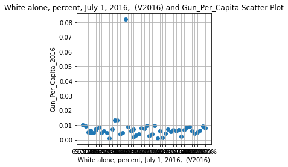

```
Persons 65 years and over, percent, April 1, 2010
```

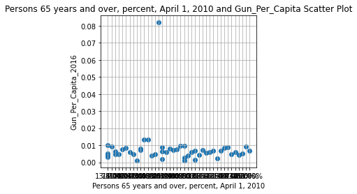

```
Owner-occupied housing unit rate, 2011-2015
```

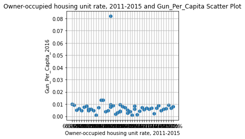

```
Asian alone, percent, July 1, 2016,  (V2016)
```

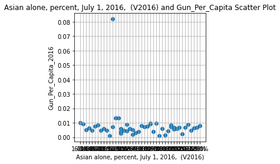

```
Foreign born persons, percent, 2011-2015
```

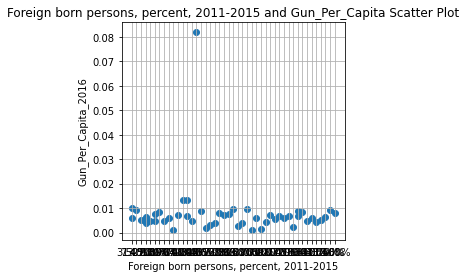

```
Median gross rent, 2011-2015
```

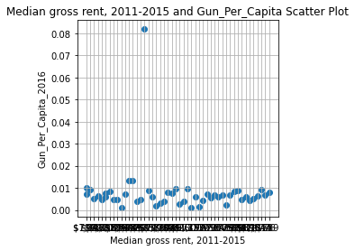

```python
valid_variable = sensible_data.drop(['guns_per_capita_2010','state','totals_y','totals_x'],axis=1)

#listed variables
imp =['White alone, percent, July 1, 2016,  (V2016)',
    'Persons 65 years and over, percent, April 1, 2010',
    'Owner-occupied housing unit rate, 2011-2015',
    'Asian alone, percent, July 1, 2016,  (V2016)',
    'Foreign born persons, percent, 2011-2015',
    'Median gross rent, 2011-2015']

#plot
for col in imp:
    plt.figure(figsize=(4,4))
    print(col)
    plt.scatter(valid_variable[col],valid_variable['guns_per_capita_2016'], label =col)
#titles/Labels
    plt.title(col+" and Gun_Per_Capita Scatter Plot")
    plt.ylabel("Gun_Per_Capita_2016")
    plt.xlabel(col)
    plt.grid(True)
    plt.show()
```

### Research Question 2 (Which states have had the highest growth in gun registrations?)

```python
merge_gun.head()
```

|  | month_x | state | totals_x | month_y | totals_y |
| --- | --- | --- | --- | --- | --- |
| 0 | 2010-04-01 | Alabama | 20791 | 2016-07-01 | 48927 |
| 1 | 2010-04-01 | Alaska | 6411 | 2016-07-01 | 6793 |
| 2 | 2010-04-01 | Arizona | 16578 | 2016-07-01 | 34496 |
| 3 | 2010-04-01 | Arkansas | 14563 | 2016-07-01 | 19378 |
| 4 | 2010-04-01 | California | 80750 | 2016-07-01 | 190218 |

```python
#insert a new column to calculate the growth in gun registration
merge_gun.insert(loc=5, column='growth_in_gun_registration', value='')
merge_gun.head()
```

|  | month_x | state | totals_x | month_y | totals_y | growth_in_gun_registration |
| --- | --- | --- | --- | --- | --- | --- |
| 0 | 2010-04-01 | Alabama | 20791 | 2016-07-01 | 48927 |  |
| 1 | 2010-04-01 | Alaska | 6411 | 2016-07-01 | 6793 |  |
| 2 | 2010-04-01 | Arizona | 16578 | 2016-07-01 | 34496 |  |
| 3 | 2010-04-01 | Arkansas | 14563 | 2016-07-01 | 19378 |  |
| 4 | 2010-04-01 | California | 80750 | 2016-07-01 | 190218 |  |

Calculate the growth in gun registration and store the results in percentage

```python
#Populate growth_in_gun_registration in percentage
merge_gun['growth_in_gun_registration'] = ((merge_gun['totals_y'] - merge_gun['totals_x'])/(merge_gun['totals_y']))*100
merge_gun.head()
```

|  | month_x | state | totals_x | month_y | totals_y | growth_in_gun_registration |
| --- | --- | --- | --- | --- | --- | --- |
| 0 | 2010-04-01 | Alabama | 20791 | 2016-07-01 | 48927 | 57.506080 |
| 1 | 2010-04-01 | Alaska | 6411 | 2016-07-01 | 6793 | 5.623436 |
| 2 | 2010-04-01 | Arizona | 16578 | 2016-07-01 | 34496 | 51.942254 |
| 3 | 2010-04-01 | Arkansas | 14563 | 2016-07-01 | 19378 | 24.847766 |
| 4 | 2010-04-01 | California | 80750 | 2016-07-01 | 190218 | 57.548707 |

```python
merge_gun.tail()
```

|  | month_x | state | totals_x | month_y | totals_y | growth_in_gun_registration |
| --- | --- | --- | --- | --- | --- | --- |
| 45 | 2010-04-01 | Virginia | 44137 | 2016-07-01 | 43574 | -1.292055 |
| 46 | 2010-04-01 | Washington | 27816 | 2016-07-01 | 47887 | 41.913254 |
| 47 | 2010-04-01 | West Virginia | 11180 | 2016-07-01 | 16791 | 33.416711 |
| 48 | 2010-04-01 | Wisconsin | 16471 | 2016-07-01 | 38922 | 57.682031 |
| 49 | 2010-04-01 | Wyoming | 4013 | 2016-07-01 | 4585 | 12.475463 |

*Get the top 5 states with the highest growth in gun registration*

```python
#Sort by growth_in_gun_registration
merge_gun.sort_values(by=['growth_in_gun_registration'], axis = 0, ascending = False).head()
```

|  | month_x | state | totals_x | month_y | totals_y | growth_in_gun_registration |
| --- | --- | --- | --- | --- | --- | --- |
| 13 | 2010-04-01 | Indiana | 25232 | 2016-07-01 | 88340 | 71.437627 |
| 7 | 2010-04-01 | Delaware | 1439 | 2016-07-01 | 4494 | 67.979528 |
| 12 | 2010-04-01 | Illinois | 53929 | 2016-07-01 | 168227 | 67.942720 |
| 17 | 2010-04-01 | Louisiana | 13373 | 2016-07-01 | 41063 | 67.432969 |
| 8 | 2010-04-01 | Florida | 42794 | 2016-07-01 | 125208 | 65.821673 |

The top 5 states are :

1. Indiana - Highest growth in gun registration
2. Delaware
3. Illinois
4. Louisiana
5. Florida

*Get the last 5 states with the least growth in gun registration*

```python
merge_gun.sort_values(by=['growth_in_gun_registration'], axis = 0, ascending = False).tail()
```

|  | month_x | state | totals_x | month_y | totals_y | growth_in_gun_registration |
| --- | --- | --- | --- | --- | --- | --- |
| 25 | 2010-04-01 | Montana | 8367 | 2016-07-01 | 9869 | 15.219374 |
| 49 | 2010-04-01 | Wyoming | 4013 | 2016-07-01 | 4585 | 12.475463 |
| 1 | 2010-04-01 | Alaska | 6411 | 2016-07-01 | 6793 | 5.623436 |
| 45 | 2010-04-01 | Virginia | 44137 | 2016-07-01 | 43574 | -1.292055 |
| 43 | 2010-04-01 | Utah | 109391 | 2016-07-01 | 17608 | -521.257383 |

Utah has the least growth in gun registration infact no growth rather than a decline. Both Utah and Virginia have a decline in gun purchase.

```python
# Drop states with negative growth for better visualization
plot_gun = merge_gun.drop([45,43])
plot_gun.tail()
```

|  | month_x | state | totals_x | month_y | totals_y | growth_in_gun_registration |
| --- | --- | --- | --- | --- | --- | --- |
| 44 | 2010-04-01 | Vermont | 2053 | 2016-07-01 | 2674 | 23.223635 |
| 46 | 2010-04-01 | Washington | 27816 | 2016-07-01 | 47887 | 41.913254 |
| 47 | 2010-04-01 | West Virginia | 11180 | 2016-07-01 | 16791 | 33.416711 |
| 48 | 2010-04-01 | Wisconsin | 16471 | 2016-07-01 | 38922 | 57.682031 |
| 49 | 2010-04-01 | Wyoming | 4013 | 2016-07-01 | 4585 | 12.475463 |

View if Utah and Virginia have been dropped.

```python
plot_gun.sort_values(by=['growth_in_gun_registration'], axis = 0, ascending = False).tail()
```

|  | month_x | state | totals_x | month_y | totals_y | growth_in_gun_registration |
| --- | --- | --- | --- | --- | --- | --- |
| 27 | 2010-04-01 | Nevada | 9294 | 2016-07-01 | 11785 | 21.137039 |
| 14 | 2010-04-01 | Iowa | 9720 | 2016-07-01 | 11937 | 18.572506 |
| 25 | 2010-04-01 | Montana | 8367 | 2016-07-01 | 9869 | 15.219374 |
| 49 | 2010-04-01 | Wyoming | 4013 | 2016-07-01 | 4585 | 12.475463 |
| 1 | 2010-04-01 | Alaska | 6411 | 2016-07-01 | 6793 | 5.623436 |

Plot a graph to show how growth in gun registration compares per state

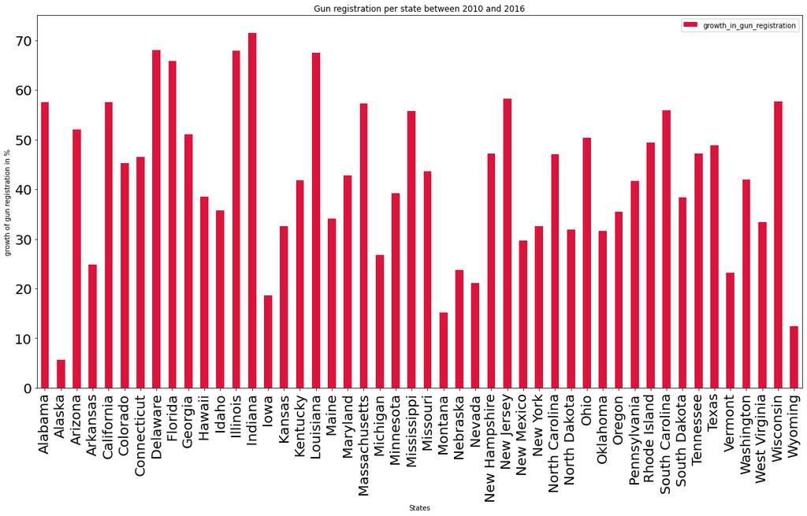

```python
plot_gun.plot(x='state', y='growth_in_gun_registration',color='crimson', kind='bar',figsize = (20,10), xlabel='States', ylabel='growth of gun registration in %',title='Gun registration per state between 2010 and 2016', fontsize=20)
```

**From the graph we can confirm that Indiana had the highest growth in gun registration between 2010 and 2016**

### Research Question 3 (What is the overall trend of gun purchases?)

We will approach this in two ways:

1. *The most bought gun models in a specific year*
2. *Gun purchase over the given years*

Lets begin with the gun models

```python
df_gun.head()
```

|  | month | state | permit | permit_recheck | handgun | long_gun | other | multiple | admin | prepawn_handgun | ... | returned_other | rentals_handgun | rentals_long_gun | private_sale_handgun | private_sale_long_gun | private_sale_other | return_to_seller_handgun | return_to_seller_long_gun | return_to_seller_other | totals |
| --- | --- | --- | --- | --- | --- | --- | --- | --- | --- | --- | --- | --- | --- | --- | --- | --- | --- | --- | --- | --- | --- |
| 0 | 2017-09 | Alabama | 16717.0 | 0.0 | 5734.0 | 6320.0 | 221.0 | 317 | 0.0 | 15.0 | ... | 0.0 | 0.0 | 0.0 | 9.0 | 16.0 | 3.0 | 0.0 | 0.0 | 3.0 | 32019 |
| 1 | 2017-09 | Alaska | 209.0 | 2.0 | 2320.0 | 2930.0 | 219.0 | 160 | 0.0 | 5.0 | ... | 0.0 | 0.0 | 0.0 | 17.0 | 24.0 | 1.0 | 0.0 | 0.0 | 0.0 | 6303 |
| 2 | 2017-09 | Arizona | 5069.0 | 382.0 | 11063.0 | 7946.0 | 920.0 | 631 | 0.0 | 13.0 | ... | 0.0 | 0.0 | 0.0 | 38.0 | 12.0 | 2.0 | 0.0 | 0.0 | 0.0 | 28394 |
| 3 | 2017-09 | Arkansas | 2935.0 | 632.0 | 4347.0 | 6063.0 | 165.0 | 366 | 51.0 | 12.0 | ... | 0.0 | 0.0 | 0.0 | 13.0 | 23.0 | 0.0 | 0.0 | 2.0 | 1.0 | 17747 |
| 4 | 2017-09 | California | 57839.0 | 0.0 | 37165.0 | 24581.0 | 2984.0 | 0 | 0.0 | 0.0 | ... | 0.0 | 0.0 | 0.0 | 0.0 | 0.0 | 0.0 | 0.0 | 0.0 | 0.0 | 123506 |

5 rows × 27 columns

```python
#We'll analyse for 2017
guns_of_2017=df_gun[df_gun['month'].str.match('2017')]
guns_of_2017.head()
```

|  | month | state | permit | permit_recheck | handgun | long_gun | other | multiple | admin | prepawn_handgun | ... | returned_other | rentals_handgun | rentals_long_gun | private_sale_handgun | private_sale_long_gun | private_sale_other | return_to_seller_handgun | return_to_seller_long_gun | return_to_seller_other | totals |
| --- | --- | --- | --- | --- | --- | --- | --- | --- | --- | --- | --- | --- | --- | --- | --- | --- | --- | --- | --- | --- | --- |
| 0 | 2017-09 | Alabama | 16717.0 | 0.0 | 5734.0 | 6320.0 | 221.0 | 317 | 0.0 | 15.0 | ... | 0.0 | 0.0 | 0.0 | 9.0 | 16.0 | 3.0 | 0.0 | 0.0 | 3.0 | 32019 |
| 1 | 2017-09 | Alaska | 209.0 | 2.0 | 2320.0 | 2930.0 | 219.0 | 160 | 0.0 | 5.0 | ... | 0.0 | 0.0 | 0.0 | 17.0 | 24.0 | 1.0 | 0.0 | 0.0 | 0.0 | 6303 |
| 2 | 2017-09 | Arizona | 5069.0 | 382.0 | 11063.0 | 7946.0 | 920.0 | 631 | 0.0 | 13.0 | ... | 0.0 | 0.0 | 0.0 | 38.0 | 12.0 | 2.0 | 0.0 | 0.0 | 0.0 | 28394 |
| 3 | 2017-09 | Arkansas | 2935.0 | 632.0 | 4347.0 | 6063.0 | 165.0 | 366 | 51.0 | 12.0 | ... | 0.0 | 0.0 | 0.0 | 13.0 | 23.0 | 0.0 | 0.0 | 2.0 | 1.0 | 17747 |
| 4 | 2017-09 | California | 57839.0 | 0.0 | 37165.0 | 24581.0 | 2984.0 | 0 | 0.0 | 0.0 | ... | 0.0 | 0.0 | 0.0 | 0.0 | 0.0 | 0.0 | 0.0 | 0.0 | 0.0 | 123506 |

5 rows × 27 columns

Getting the total purchase numbers of various gun models

```python
guns_of_2017['handgun'].sum()
```

```
5231079.0
```

```python
guns_of_2017['long_gun'].sum()
```

```
3419092.0
```

```python
guns_of_2017['multiple'].sum()
```

```
169062
```

```python
guns_of_2017['other'].sum()
```

```
276527.0
```

Most purchased model is the Handgun while purchase of multiple models was the least.

We will create lists of the models and their totals to prepare for visualization

```python
#create a list of firearms
the_guns = ['Handgun', 'Long Gun', 'Multiple', 'other']
```

```python
#A list of the total no. of the 'the_guns'
num_of_guns = [5231079.0, 3419092.0, 169062, 276527.0]
```

```python
ticks_of_guns = np.arange(len(the_guns))
```

```python
# A function to divide the totals by a million for a sensible visualization
def perMillion(ticks_of_guns, pos):
    return (ticks_of_guns/1e6)
```

Plot a graph showing the number of guns purchased for each type of firearm

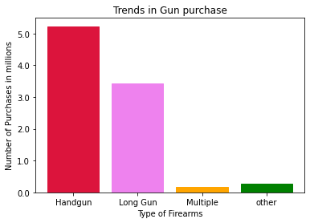

```python
fig, ax = plt.subplots()

#Titles/labels
plt.title('Trends in Gun purchase')
ax.yaxis.set_major_formatter(perMillion)
plt.ylabel('Number of Purchases in millions')
plt.xlabel('Type of Firearms')

#Set the colors of the bars
color=plt.bar(ticks_of_guns, num_of_guns)
color[0].set_color('crimson')
color[1].set_color('violet')
color[2].set_color('orange')
color[3].set_color('green')

plt.xticks(ticks_of_guns, the_guns)
plt.show()
```

The second approach:  
Gun purchase over the given years

*To achieve this we need to create a column for years that will be used for visualization*

```python
#Extract years from month column and create a column for years
df_gun['year']=df_gun['month'].apply(lambda x: x.split("-")[0]).astype(int)
df_gun['year'].unique()
```

```
array([2017, 2016, 2015, 2014, 2013, 2012, 2011, 2010, 2009, 2008, 2007,
       2006, 2005, 2004, 2003, 2002, 2001, 2000, 1999, 1998])
```

```python
#confirm year column has been added and populated
df_gun.head(1)
```

|  | month | state | permit | permit_recheck | handgun | long_gun | other | multiple | admin | prepawn_handgun | ... | rentals_handgun | rentals_long_gun | private_sale_handgun | private_sale_long_gun | private_sale_other | return_to_seller_handgun | return_to_seller_long_gun | return_to_seller_other | totals | year |
| --- | --- | --- | --- | --- | --- | --- | --- | --- | --- | --- | --- | --- | --- | --- | --- | --- | --- | --- | --- | --- | --- |
| 0 | 2017-09 | Alabama | 16717.0 | 0.0 | 5734.0 | 6320.0 | 221.0 | 317 | 0.0 | 15.0 | ... | 0.0 | 0.0 | 9.0 | 16.0 | 3.0 | 0.0 | 0.0 | 3.0 | 32019 | 2017 |

1 rows × 28 columns

A function that will plot graphs of gun purchase in various months of the year over a period of time and gun purchase being compared between a period of years.

```python
def mytrendPlot(df_gun, grpVar, yVar, color= None):
#Create line chart using grouped data by year ,month, which can be used to observe the change of pattern

    #plot
    df_gun.groupby(grpVar)[yVar].sum().plot(figsize=[20,10],color=color);

    #tidy up the labels
    grpVar = grpVar.replace("_", " ")

    #if yVar is a list, combine the items into a string
    if isinstance(yVar, list):
        yVar=' & '.join(yVar)
    else:
        yVar = yVar.replace("_", " ")

    #Title
    plt.title(f'Overall trend per {grpVar}',fontsize = 20)

    #Labels
    plt.xlabel('Time',fontsize = 20)
    plt.ylabel('Count in millions',fontsize = 10)
    plt.legend(fontsize = 25)
```

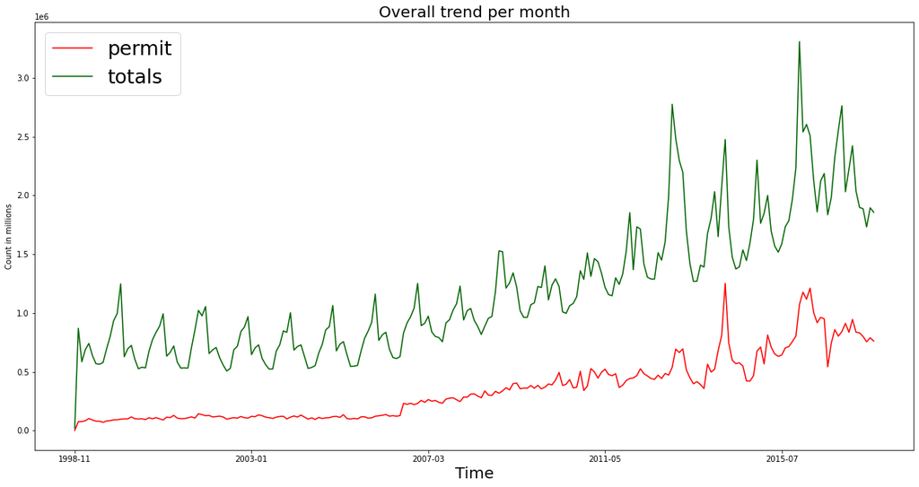

```python
# Gun purchase in various months of the year over a period of time
mytrendPlot(df_gun, 'month', ['permit', 'totals'], color=['red', 'darkgreen'])
```

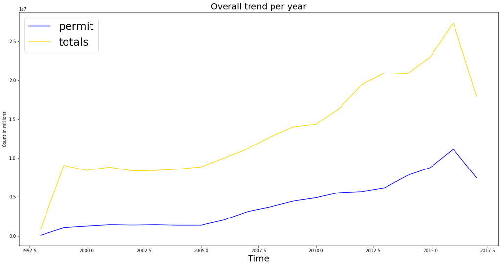

```python
# Gun purchase being compared between a period of years ie (1998-2017)
mytrendPlot(df_gun, 'year', ['permit', 'totals'], color=['blue', 'gold'])
```

## Conclusions

#### Dataset Description

The US census data and Gun data are independent sources of data. However, they share a common variable which is the states and dates. These Variables were essential in data cleaning to create a common ground between the two and also provide consistency for visualization.

#### Question that were investigated

1. What census data is most associated with high gun per capita?
2. Which states have had the highest growth in gun registrations?
3. What is the overall trend of gun purchases?

#### Limitations

1. For the Census dataset, there ware missing data that might contribute in the analysis accuracy, such as the five addressed colonies; District of Columbia, Guam, Mariana Islands, Puerto Rico and Virgin Islands.
2. Missing or NaN values in the dataset, especially in 'Fact Note' column in census data
3. Standardization of datasets. Datatypes in datasets needed change of datatype for consistent and accurate analysis.

#### Findings

1. Census data that is most associated with high gun per capita.

2. States that with the highest growth in gun registrations

Top 5 states with highest growth in gun regesistration between 2010 and 2016

- Indiana with 71.437627% growth
- Delaware with 67.979528% growth
- Illinois with 67.942720% growth
- Louisiana with 67.432969% growth
- Florida with 65.821673% growth

Uttah and Virginia had a decline in gun registration with a 521.257383% and 1.292055% decrease respectively

3. The overall trend of gun purchases

Most purchased guns in 2017 are:

- Handgun with 5231079 as the number of purchase
- Long gun with 3419092 as the number of purchase
- Others with 276527 as the number of purchase
- Multiple with 169062 as the number of purchase

## REFERENCES

1. Salesforce. (n.d.). Guide to data cleaning: Definition, benefits, components, and how to clean your data. Tableau. Retrieved August 18, 2022, from https://www.tableau.com/learn/articles/what-is-data-cleaning
2. Stack Overflow. (n.d.). Pandas: To_numeric for multiple columns.https://stackoverflow.com/questions/36814100/pandas-to-numeric-for-multiple-columns
3. Suuuehgi. (n.d.). How to properly use FuncFormatter(func)? Stack Overflow.https://stackoverflow.com/questions/40511476/how-to-properly-use-funcformatterfunc
4. Pandas join issue: Columns overlap but no suffix specified. (n.d.). Stack Overflow. https://stackoverflow.com/questions/26645515/pandas-join-issue-columns-overlap-but-no-suffix-specified
5. How to delete rows from a pandas DataFrame based on a conditional expression. (2016, December 8). Stack Overflow. https://stackoverflow.com/questions/13851535/how-to-delete-rows-from-a-pandas-dataframe-based-on-a-conditional-expression
6. Data to Fish. (2021, September 25). How to convert strings to Datetime in pandas DataFrame. https://datatofish.com/strings-to-datetime-pandas/
7. Pandas setting multi-index on rows, then transposing to columns. (n.d.). Stack Overflow. https://stackoverflow.com/questions/38980714/pandas-setting-multi-index-on-rows-then-transposing-to-columns

Repositories that were helpful

1. Yara-Aldajjani/FBI-Gun-Data-Analysis
2. [Hwangmpaula/FBI-gun-data-analysis](https://github.com/hwangmpaula/FBI-gun-data-analysis)
3. [Alicelibinguo/Investigate-FBI-Gun-Data](https://github.com/Alicelibinguo/Investigate-FBI-Gun-Data')
4. [Imsingla/Investigate-FBI-NCIS-Gun-Data](https://github.com/imsingla/Investigate-FBI-NCIS-Gun-Data')

```python
from subprocess import call
call(['python', '-m', 'nbconvert', 'investigate-a-dataset.ipynb'])
```

```
1
```